# Land use

## PMD (Coderre administration):

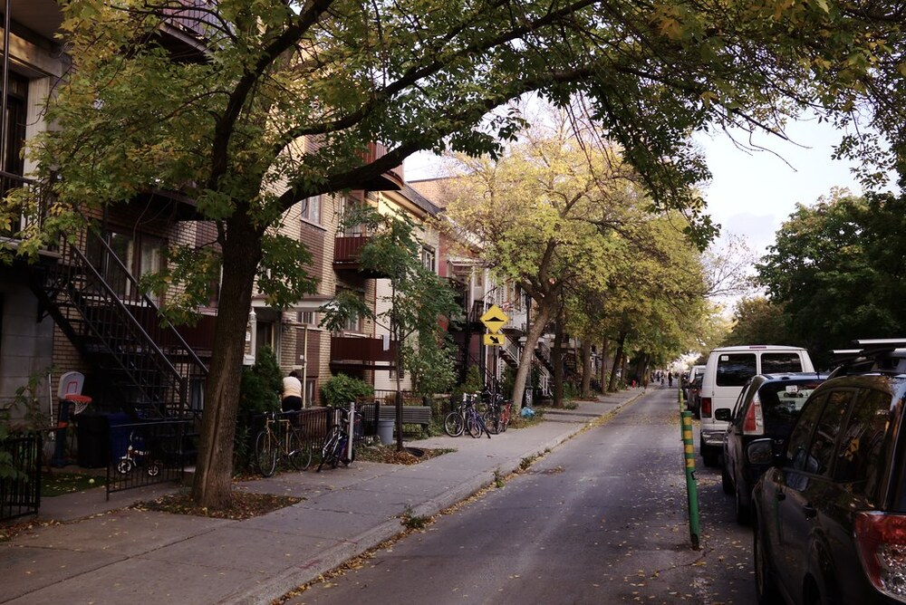

The PMD does not include any land use-specific policies. It is geared towards introducing green infrastructure and low-emissions mobility into existing neighbourhoods. While “human-scale” neighbourhoods are discussed and are among the plan’s central goals, no mechanism is proposed to modify land use to create or preserve such areas.

## Plan climat (Plante administration):

Improve the city’s planning tools to favour building human-scale neighbourhoods adapted to climate change with mixed uses, resiliency, greenery, active transportation and services in mind. Convert open-air parking lots into dense housing or green space. Create carbon-neutral neighbourhoods (écoquartiers carboneutres), using the ongoing Hippodrome development as a model.

## Discussion

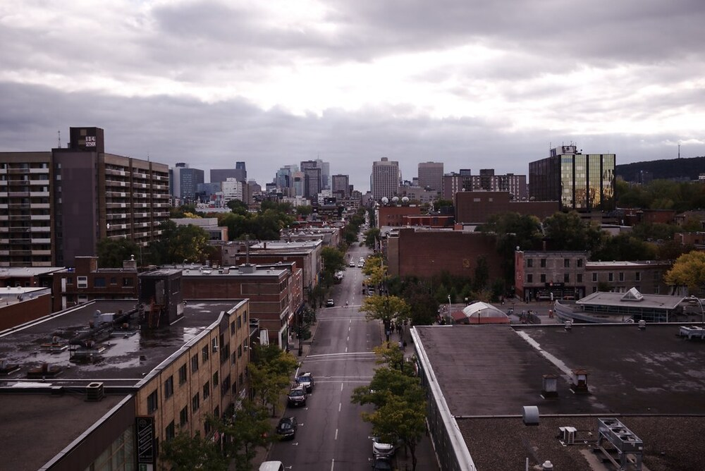

While neither plan delves deeply into land-use, the PMD avoids the issue entirely. The Plan climat, on the other hand, discusses non-specific changes to the city’s land use practices encouraging denser urban form, reduced automobile use, public transport use and taking into account climate hazards. The Plan climat is more inclined to discuss rewriting bylaws, experimenting with new urban forms and building on successful ones. The wishlist for Montreal’s neighbourhoods of the future (mixed uses, resiliency, green, active and nearby to services) may end up having influence outside of simple notions of land use and zoning, impacting other policy categories in this paper (greening, economy, equity, etc.). This is encouraging, but in absence of follow-up, it will be difficult to determine what changes, if any, have been made.